# Earth Observation to support agronomic advice

Leroux Louise, Gosh Payel, Srivastava Amit, Chernet Meklit

2024-05-13

> Owing to its large area and repetitive coverage at relatively low cost, Earth Observation (EO) has been used for decades for crop vegetation monitoring at different spatial scales. Compared to crop growth models, remote sensing provides a physical measurement of crop vegetation and its temporal and spatial development and hence are very usefull to monitor actual crop development. Within AgWISE, EO and statistical models are combined to provide complementary information to crop models on crop developpement. Particularly we provide information on the crop type area and crop planting date.

# The AgWISE Remote Sensing module : Quesaco?

The objective of the AgWISE Remote Sensing module is to provide information on **crop type probability areas and crop planting dates** based on EO and using cutting-edge data analytics. Crop type probability areas maps allow to have information on where each crops is predominantly grown and hence can be used to **refine agronomic advises** (eg. fertilizer recommendation) based on the areas actually covered by the crop. The crop planting dates information are used to supplement the information provided by crop models and to all the end users to have a comparison between the actual planting dates (ie. coming from EO) and the optimal planting date (ie. coming from the crop model). This can serve as a basis for **yield gap analysis** but also to better understand **farmers adaptations to climate change**. The AgWISE Remote Sensing module has been designed to be able to run at large scale (up to national scale) while using a minimum ground data as input. It relies on two type of information:

- *Earth Observation*:
  - **MODIS NDVI** (Normalized Difference Vegetation Index) : MODIS sensors provide the longest time series of information (ie. from 2000 to 2023) on vegetation development at a spatial resolution of 250-m and a 8-days temporal resolution.
  - **ESA World Cover** : providing land cover information, including cropland information, at 10-m spatial resolution.
- *Ground data* :
  - **On planting date** : providing information on the actual planting date as observed by farmers. Those data are used to validate our planting date estimation
  - **On crop type field location** : providing GPS coordinates of crop fields. Those data are used to train and validate our crop type model.

We provide crop type probabilities areas and actual planting date aggregated at administrative levels.

> Note : MODIS satellites have been decommissioned on December, 2023. An adaptation of the present workflow relying on VIIRS data is scheduled.

A detailed documentation on how to run the AgWISE Remote Sensing module is provided in [Github](https://github.com/AgWise-showcase/demo-repository/blob/main/Script/RS_Actual_Planting/generic/Agwise_RS_module_workflow_SA.html).

# EO data and pre-processing

## MODIS NDVI Data

The backbone of our approach relies on a time series of MODIS Normalized Difference Vegetation Index (combining AQUA and TERRA) that are downloaded over cropping seasons for a targeted area. The MODIS VI products (collection 6) consists of 8-day NDVI average values at a spatial resolution of 250 m. Most of farmers fields in our targeted study areas are considered as small to very small fields (below 1 ha) and hence the MODIS spatial resolution is considered as too coarse to provide reliable information at field farmers scale. However, due to its high temporal resolution, it allows to catch general patterns in crop development at regional scale. A Savitzky-Golay temporal filter algorithm is used for smoothing the time series in order to remove remaining atmospheric noise and provide a time series with an improved quality (Figure 1).

The script to automatically download MODIS data is provided in [Github](https://github.com/AgWise-showcase/demo-repository/blob/main/Script/RS_Actual_Planting/generic/get_MODISdata_SA.R) and to pre-process the NDVI time series in [Github](https://github.com/AgWise-showcase/demo-repository/blob/main/Script/RS_Actual_Planting/generic/get_MODISts_PreProc_SA.R)

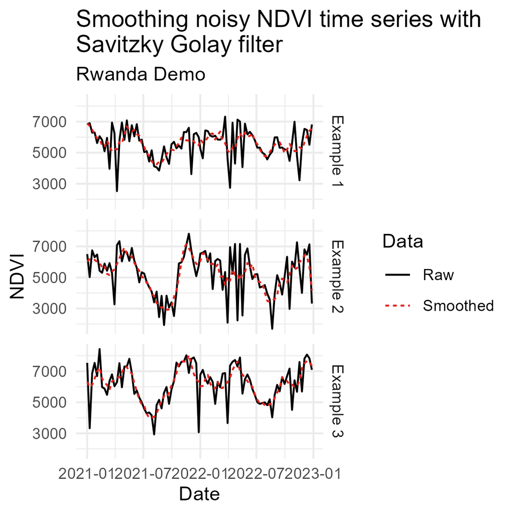

Figure 1. Smoothing of NDVI time series with the Savitzky Golay filter in Rwanda for the 2021-2022 cropping season.

## ESA World Cover

The European Space Agency (ESA) WorldCover 10 m 2020 product is used to mask-out non cropped pixels from our workflow. It provides a global land cover map for 2020 at 10 m resolution based on Sentinel-1 and Sentinel-2 data, including one cropland class. The product is resampled at a spatial resolution of 250-m to match the MODIS spatial resolution.

The script to automatically download ESA World Cover data is provided in [Github](https://github.com/AgWise-showcase/demo-repository/blob/main/Script/RS_Actual_Planting/generic/get_ESACropland_fromGEE.html)

# Getting the crop type probability and planting date maps

## Crop type probability map

The crop type probability map is derived from MODIS NDVI time series combined with a machine learning framework. Given the small size of most of farmers fields compared to the MODIS spatial resolution, our aim is not to provide a crop type map at field scale but rather to provide, for a specific cropping season, a picture of where a given crop is cultivated. Therefore we refer to a crop type probability map since if a given pixel is classified as a crop it doesn’t mean that all the area is cultivated with this crop but rather that we can find this specific crop within this pixel unit. Most of ground data coming from agronomic experiments provide only information on the presence of a given crop (ie. GPS coordinates are available only for the targeted fields) while to be able to map the presence of a specific crop, we also need to have information on its absence. Hence to deal with that common issue in most of the dataset coming from agronomic experiments, we propose an original approach relying on a unsupervised learning to build a presence/absence dataset based on the presence data only. Then, 5 types machine learning algorithms (ie. linear model, non-linear model, tree, boosting ensemble and bagging ensemble) are calibrated and validated. The 3 algorithms reaching the highest accuracies in validation are then ensemble to produce the final crop type probability maps. Figure 2 show an example of output for Maize in Rwanda over the 2021-2022 cropping season. The overall accuracy ranges between 0.70 and 0.72 depending on the algorithm.

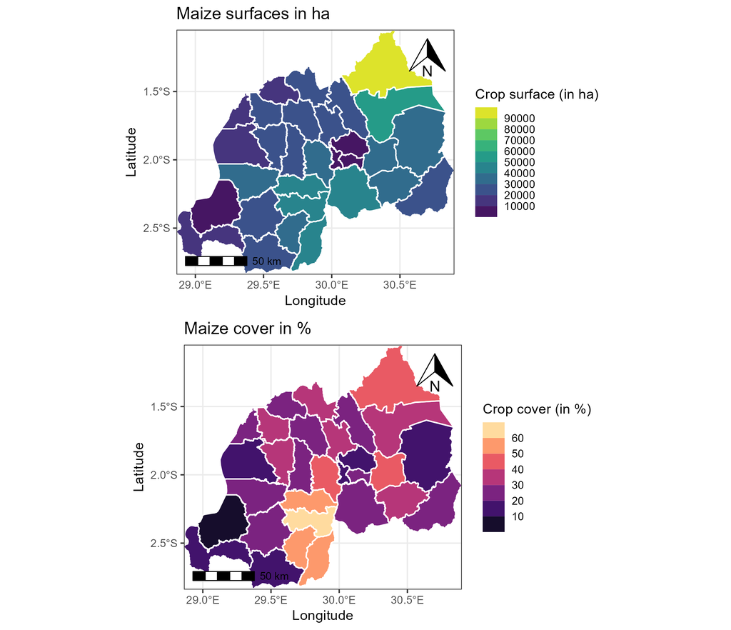

The script to run the crop type workflow is provided in [Github](https://github.com/AgWise-showcase/demo-repository/blob/main/Script/RS_Actual_Planting/generic/get_RS_Croptype_SA.R)

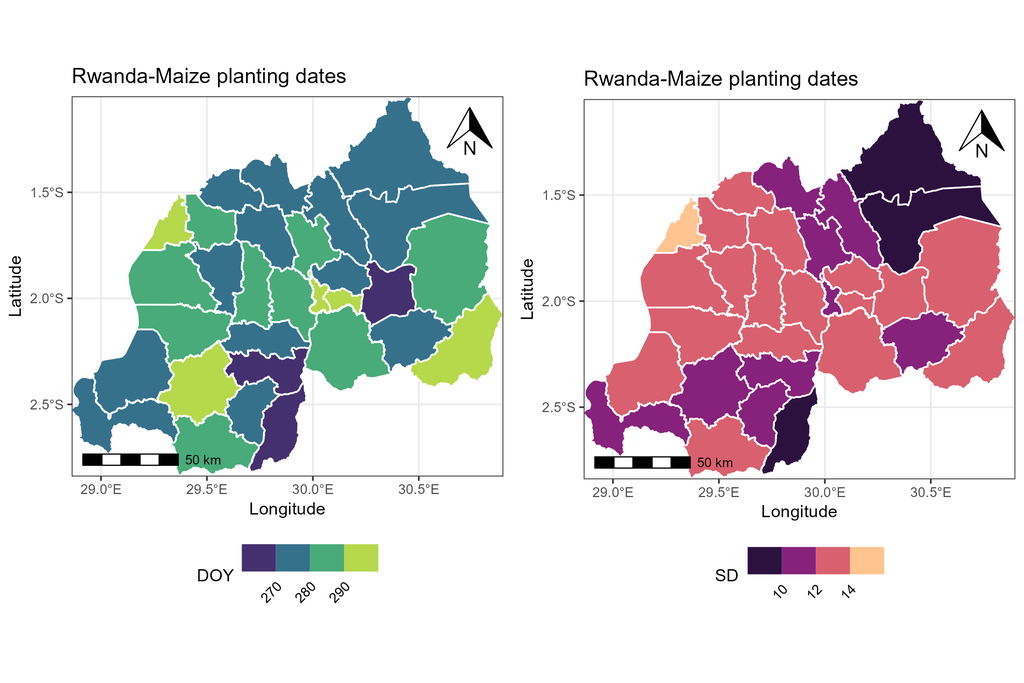

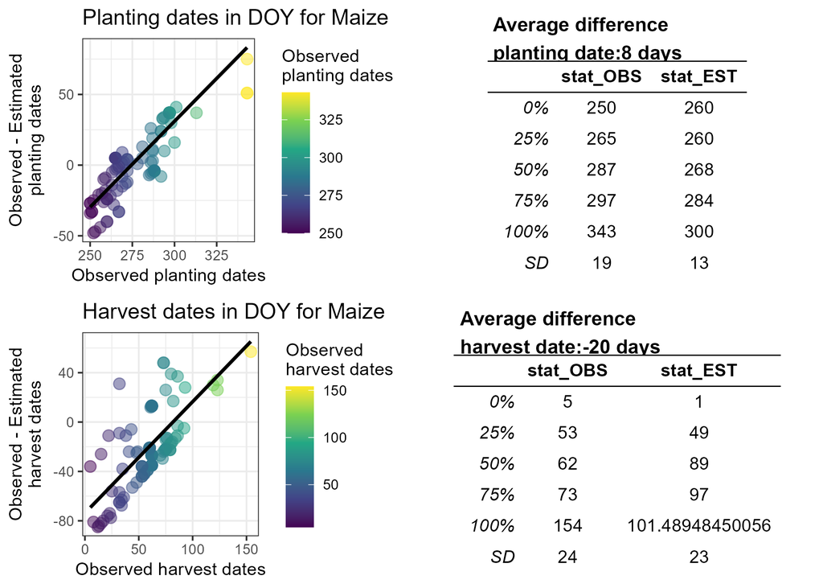

The script to run the planting dates workflow is provided in [Github](https://github.com/AgWise-showcase/demo-repository/blob/main/Script/RS_Actual_Planting/generic/get_RS_Phenology_SA.R)